# Covid Analysis Matteo Bracco

# Introduction

In this notebook we look for data which can be analyzed through the LGCA model. First, we will need data coming from a small population, to be able to run an LGCA simulation from my Laptop. A good possibility is to use data coming from low density areas, for instance some county in Alaska will do. We will firstly try to use those data to estimate the $R_0$ parameter of the classic SIR model, through the package “R0”, using the so called Exponential Growth Method.

To do so we need to find period of times in which the increase of the infected population $I$ is exponential, i.e the increase of new confirmed cases by day is linear.

We will then use $R_0$ with the other SIR parameters to run an LGCA and some Modified LGCA simulations in pyhton, and we will compare the results with SIR simulations and real data here on this notebook

Let’s start by implementing the necessary library, importing the data and define some functions to visualize time series with ggplot2. The data selected comes from the Kodiak Island Area in Alaska. Its population from 2020 found in [censu.gov](https://www.census.gov) was of $13100$ people.

```r
library("R0")                           # To evaluate R0
library("zoo")                          # For rollmean
library("ggplot2")                      # For nice time series plots
library(deSolve)
library("reticulate")
library(tidyr)
library(dplyr)
#infections=read.csv("epidemiology.csv") # Data

# This function allows to plot obs against date, where
# obs is the collection of new registered infections, with respect to the dates
# stored in data
infected_series=function(date,obs){
  df=data.frame(date,obs)
  p=ggplot(df, aes(x = as.Date(date), y = obs)) +
  geom_line()+
  xlab("date")
  return(p)
}

Multiple_series=function(df){
  di <- df %>%
  pivot_longer(cols = -times, names_to = "Infected", values_to = "Infected_Obs")

  p=ggplot(di, aes(x = as.Date(times), y = Infected_Obs, color = Infected)) +
  geom_line(size = 1) +
  labs(title = "New Infected per day",
       x = "Date", y = "Value", color = "Observation") +
  theme_minimal()
  return(p)
}
```

# Estimating Parameters for our simulations

## Estimating $R_0$

We start by plotting the registered infected population over time.

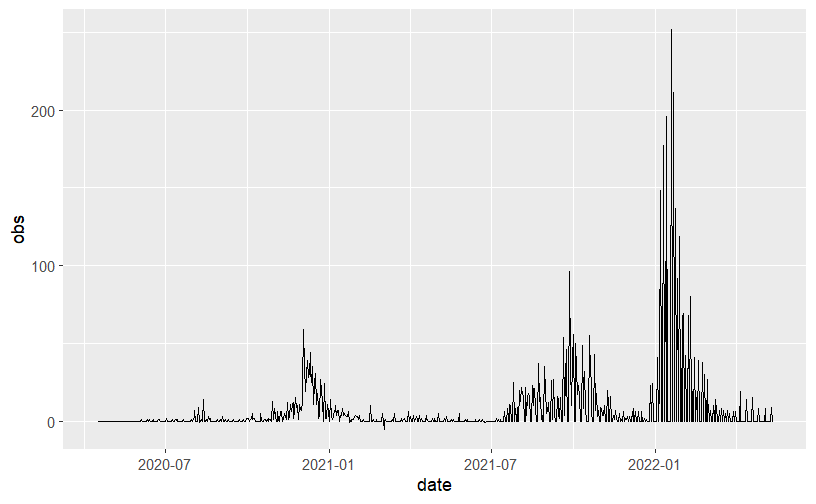

```r
Inf_AL=subset(infections, location_key == "US_AK_02150")

infected_series(Inf_AL$date,Inf_AL$new_confirmed)
```

We can see that there are three separate epidemic peeks. Note that for the last two peeks, there is a big heterogeneity in the registration of new infected, represented by the big jumps in our time series, this can be caused by different flows in the data collection procedure, for instance all the new cases where registered at the end of the week instead of being registered day by day.

This pehonomenon is also present in the first peak, but it’s less impactful, which probably means that the lower number of registered people can be linked to the lower number of tested people, which unfortunately is not an available data for this subset, but also for other similar subsets of small population that I tries out.

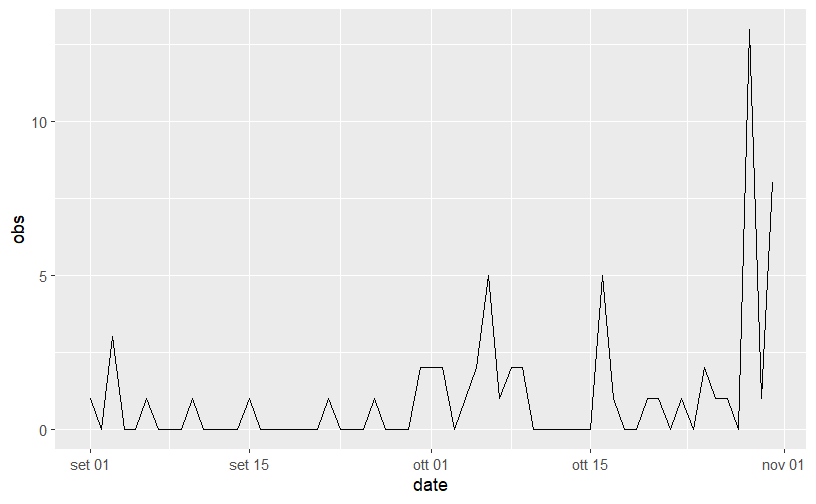

```r
start=which(Inf_AL$date=="2020-09-01")
stop=which(Inf_AL$date=="2020-10-31")
obs=Inf_AL$new_confirmed[start:stop]
date=Inf_AL$date[start:stop]
infected_series(date,obs)
```

[figure not shown]

```r
new_stop=stop+4
obs_roll=ceiling(rollmean(Inf_AL$new_confirmed[start:new_stop], k=5, align='right'))
infected_series(date,obs_roll)
```

We can see clearly that the exponential grow happens from the last days of November to the $5$-$15^{th}$ of December. Precisely we choose the following as the exponential growth period

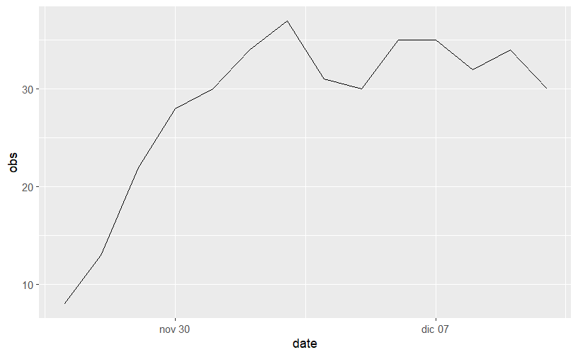

```r
start2=which(new_df$date=="2020-11-27")
stop2=which(new_df$date=="2020-12-10")
date_exp=date[start2:stop2]
obs_roll_exp=obs_roll[start2:stop2]

infected_series(date_exp,obs_roll_exp)
```

We are then ready to evaluate $R0$ with the Exponential Growth Method. To do so we use the command *estimate.R* od the package *R0* passing as the method option the string “EG”, which stands for Exponential Growth.

```r
# Create a named vector where dates are names
data_rolls <- setNames(obs_roll_exp, date_exp)




mGT <- generation.time("gamma", c(3, 1.5))
R0 <- estimate.R(data_rolls, mGT, methods=c("EG"),
                    pop.size=N, nsim=800)
R0
```

```
Reproduction number estimate using  Exponential Growth  method.
R :  1.970491[ 1.54111 , 2.506963 ]
```

We will use the value $R0=1.970491$ to run our LGCA simulation in python. Moreover, limiting the time span to $100$ days halves the computational times, making it suitable for a Laptop simulation.

## The Initial Number of Infected People and the Starting Date

We now need to understand when the epidemic started and the initial number of infected people. To do so we can visualize the number of new infected in the months priors to November

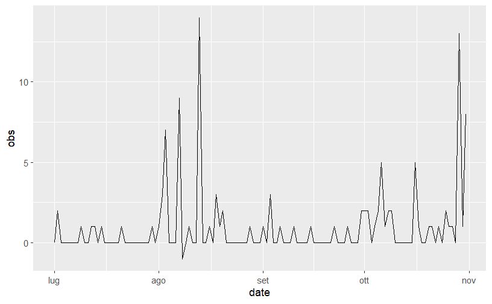

```r
start=which(Inf_AL$date=="2020-07-01")
stop=which(Inf_AL$date=="2020-10-31")
obs=Inf_AL$new_confirmed[start:stop]
date=Inf_AL$date[start:stop]
infected_series(date,obs)
```

As we can see there was a small peak around August, afterwards the situation seemed to be stable with almost no new positive cases between September and the start of October Hence we can reasonably start our Simulation at the beginning of October. Note that previously there where not some big wawes of Covid-19 in the Area, so we can assume the initial value of recovered people to be $0$ for the simulation at the beginning of October.

Note that the other option would be to simulate the epidemic from the start of July, however the $R_0$ estimation has only a local value, as it may vary significantly with the change of seasons, habits and other factors we can’t take into account. Hence it is best to limit our simulations to a span of $100$ days across the autumn/winter season in Alaska.

The number of infected people at October $1^{st}$ is the most difficult parameter to estimate, we can start by evaluating the sum in the $5$ preceding days of the registered infected individuals

```r
end=which(Inf_AL$date=="2020-10-01")
start=end-5
sum(Inf_AL$new_confirmed[start:end])
```

```
[1] 5
```

## Parameters for the Simulations

We can the visualize the initial values and parameters for our LGCA and SIR simulations below.

```r
R0=1.970491
startN=which(Inf_AL$date=="2020-10-01")
endN=which(Inf_AL$date=="2021-01-09")
I0=max(Inf_AL$new_confirmed[startN:endN])
date0="2020-10-01"
N=13100
gamma=1/6.5
beta=gamma*R0

Parameter=c("Starting Date","Total Population","Initial Population of Infected People","gamma","beta")
Value=c(date0,N,I0,gamma,beta)
Initial=data.frame(Parameter,Value)
Initial
```

| Parameter | Value |
| --- | --- |
| Starting Date | 2020-10-01 |
| Total Population | 13100 |
| Initial Population of Infected People | 59 |
| gamma | 0.153846153846154 |
| beta | 0.303152461538462 |

# Simulations Comparisons

We can load the number of new infected per day simulated via the LGCA simulation in python. The idea is to compare such results with real data and results of the classic SIR model.

```r
history=py_load_object("incid.pckl")
```

## SIR Model

We then need to evaluate a classic verision of the SIR model, we will use the simplest version as it is the one on which the LGCA model is built on.

```r
sir_equations <- function(time, variables, parameters) {
  with(as.list(c(variables, parameters)), {
    dS <- -B * I * S
    dI <-  B * I * S - G * I
    dR <-  G * I
    return(list(c(dS, dI, dR)))
  })
}

parameters_values <- c(
  B  = beta/N,
  G = gamma
)

initial_values <- c(
  S = N-I0,
  I =   I0,
  R =   0
)

time_values <- seq(0, 100) # days

SIR_obs =as.data.frame(ode(
  y = initial_values,
  times = time_values,
  func = sir_equations,
  parms = parameters_values
))
```

We can derive the incidence of the susceptibles with the following functions, which translates what we did in Pyhthon with the LGCA model

```r
find_incid <- function(I,R){
  n <- length(I)
  incid <- c(15)
  for (i in 2:n) {
    I_today <- I[i]
    R_new <- R[i] - R[i-1]
    I_yest <- I[i-1] - R_new
    I_new <- I_today - I_yest
    incid <- c(incid, I_new)
  }

  return(incid)
}

incid_SIR=find_incid(SIR_obs$I,SIR_obs$R)
```

We can then build a data.frame containing real data, LGCA data and SIR data and compare the results

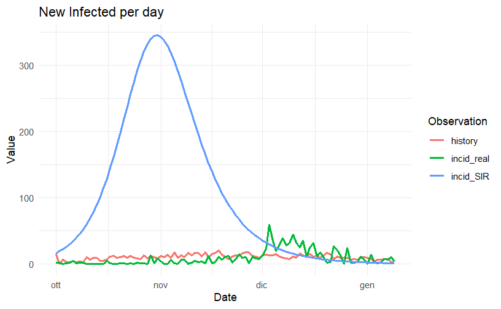

```r
start=which(Inf_AL$date==date0)
stop=start+100
times=Inf_AL$date[start:stop]
incid_real=Inf_AL$new_confirmed[start:stop]
Data_Incid=data.frame(times,incid_SIR,history,incid_real)
Multiple_series(Data_Incid)
```

The first thing we can see from the simulations of the SIR model is that the peak of new infected registrations is much larger then the real data. however, not all the infected people are really registered, hence it may as well be possible that the real number of new infected is larger then the data collected. However, the main issue we are trying to address with the LGCA model is quite noticeable from this simulation: the real peak of new infected people is shifted in time with respect to the SIR estimates.

Now, we would like to see the peak of the LGCA estimate near to the peak of the real data, however we do not even see a peak for the LGCA simulation from this visualization. Let’s remove the SIR data to have a better view of the LGCA results

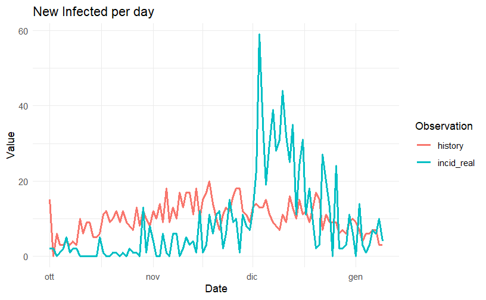

```r
Incid_new=data.frame(times,history,incid_real)
Multiple_series(Incid_new)
```

The LGCA model seems in fact to have a very small and very large peak $20$ days after the SIR model, quite closer to the real registered peak, but the estimates of the new positive cases are very low, even when compared with the registered data, and the peak is barely noticeable, and we can’t really exclude that it only happened because of stochastics effect of this specific simulation. Obviously the best solution would be to run more simulations and take the average to solve such issue, but we do not have the computational power to do so.

Nevertheless, the development of the LGCA simulation doesn’t seem to follow the real epidemic spread, even from a qualitative point of view, as we should at least see a significant increase in the new registered cases.

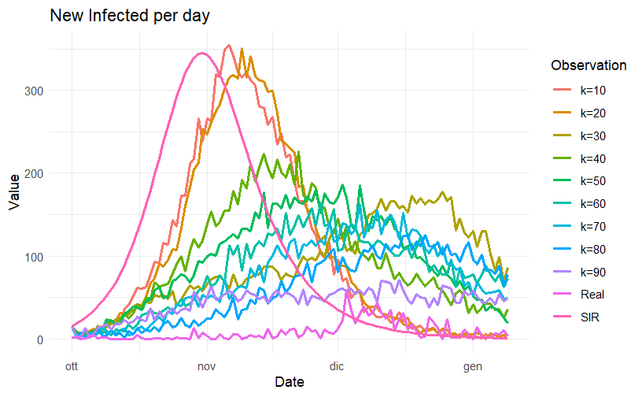

```r
new_history=py_load_object("modified10.pckl")


model100=py_load_object("Incid100.pckl")
Modified_data=data.frame(times,incid_SIR,incid_real,new_history)
colnames(Modified_data) <- c("times","SIR","Real","k=10", "k=20", "k=30","k=40", "k=50", "k=60","k=70", "k=80", "k=90")
Multiple_series(Modified_data)
```

```r
Modified_data
```

| times | incid_SIR | incid_real | c.15L..7L..5L..7L..7L..6L..12L..14L..21L..18L..21L..22L..36L.. | c.15L..4L..8L..6L..9L..12L..8L..12L..17L..18L..22L..31L..30L.. | c.15L..5L..6L..10L..8L..7L..16L..8L..15L..18L..24L..26L..28L.. | c.15L..9L..6L..6L..8L..5L..9L..12L..16L..23L..18L..24L..31L.. | c.15L..7L..7L..8L..8L..9L..11L..12L..24L..22L..18L..18L..30L.. | c.15L..2L..3L..9L..7L..8L..11L..8L..10L..5L..11L..10L..9L..18L.. | c.15L..2L..4L..3L..5L..4L..7L..15L..6L..10L..7L..10L..12L..5L.. | c.15L..4L..8L..2L..6L..5L..11L..4L..4L..10L..5L..8L..2L..9L.. | c.15L..4L..2L..13L..3L..7L..14L..15L..18L..11L..19L..18L..23L.. |
| --- | --- | --- | --- | --- | --- | --- | --- | --- | --- | --- | --- |
| 2020-10-01 | 15.000000 | 2 | 15 | 15 | 15 | 15 | 15 | 15 | 15 | 15 | 15 |
| 2020-10-02 | 19.174410 | 2 | 7 | 4 | 5 | 9 | 7 | 2 | 2 | 4 | 4 |
| 2020-10-03 | 22.186283 | 0 | 5 | 8 | 6 | 6 | 7 | 3 | 4 | 8 | 2 |
| 2020-10-04 | 25.651553 | 1 | 7 | 6 | 10 | 6 | 8 | 9 | 3 | 2 | 13 |
| 2020-10-05 | 29.631799 | 2 | 7 | 9 | 8 | 8 | 8 | 7 | 5 | 6 | 3 |
| 2020-10-06 | 34.194645 | 5 | 6 | 12 | 7 | 5 | 9 | 8 | 4 | 5 | 7 |
| 2020-10-07 | 39.413585 | 1 | 12 | 8 | 16 | 9 | 11 | 11 | 7 | 11 | 14 |
| 2020-10-08 | 45.367399 | 2 | 14 | 12 | 8 | 12 | 12 | 8 | 15 | 4 | 15 |
| 2020-10-09 | 52.139148 | 2 | 21 | 17 | 15 | 16 | 24 | 10 | 6 | 4 | 18 |
| 2020-10-10 | 59.814427 | 0 | 18 | 18 | 18 | 23 | 22 | 5 | 10 | 10 | 11 |

[output cut: 91 more lines]